# 12. 层次聚类

- scipy实现
- scikit-learn实现

层次聚类是一种用于聚类数据点的无监督学习方法。该算法通过测量数据之间的差异来构建聚类。无监督学习意味着模型不必经过训练，我们也不需要“目标”变量。此方法可用于任何数据，以可视化和解释各个数据点之间的关系。

在这里，我们将使用层次聚类对数据点进行分组，并使用树状图和散点图可视化聚类。

## 12.1 scipy实现

我们将使用凝聚聚类，这是一种遵循自下而上方法的层次聚类。我们首先将每个数据点视为自己的聚类。然后，我们将彼此之间距离最短的聚类连接在一起，以创建更大的聚类。重复此步骤，直到形成一个包含所有数据点的大聚类。

层次聚类要求我们决定距离和链接方法。我们将使用欧几里得距离和 Ward 链接方法，该方法试图最小化聚类之间的差异。

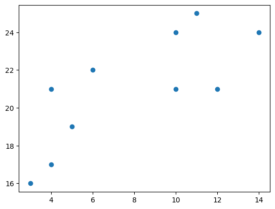

```python
import matplotlib.pyplot as plt

x = [4, 5, 10, 4, 3, 11, 14 , 6, 10, 12]
y = [21, 19, 24, 17, 16, 25, 24, 22, 21, 21]

plt.scatter(x, y)
plt.show()
```

现在我们使用欧几里得距离计算单元链接，并使用树状图将其可视化。

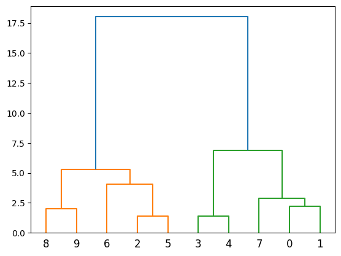

```python
from scipy.cluster.hierarchy import dendrogram, linkage

data = list(zip(x, y))

linkage_data = linkage(data, method='ward', metric='euclidean')
dendrogram(linkage_data)

plt.show()
```

## 12.2 scikit-learn实现

在这里，我们使用 Python 的 scikit-learn 库执行相同的操作。然后，在二维图上进行可视化：

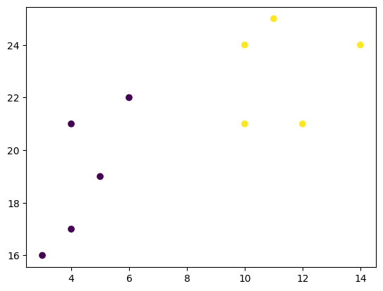

```python
from sklearn.cluster import AgglomerativeClustering

hierarchical_cluster = AgglomerativeClustering(n_clusters=2, linkage='ward', metric='euclidean')
labels = hierarchical_cluster.fit_predict(data)

plt.scatter(x, y, c=labels)
plt.show()
```